# Week 11 Day 3 Homework

```r
library(tidyverse)
library(cluster)
library(factoextra)
library(dendextend)
library(GGally)
library(broom)
```

```r
customers <- read_csv("data/mall_customers.csv") %>%
  janitor::clean_names() %>%
  rename(score = spending_score_1_100,
         income = annual_income_k)
```

## 1. Exploratory Analysis

```r
summary(customers)
```

```
##   customer_id        gender               age            income
##  Min.   :  1.00   Length:200         Min.   :18.00   Min.   : 15.00
##  1st Qu.: 50.75   Class :character   1st Qu.:28.75   1st Qu.: 41.50
##  Median :100.50   Mode  :character   Median :36.00   Median : 61.50
##  Mean   :100.50                      Mean   :38.85   Mean   : 60.56
##  3rd Qu.:150.25                      3rd Qu.:49.00   3rd Qu.: 78.00
##  Max.   :200.00                      Max.   :70.00   Max.   :137.00
##      score
##  Min.   : 1.00
##  1st Qu.:34.75
##  Median :50.00
##  Mean   :50.20
##  3rd Qu.:73.00
##  Max.   :99.00
```

No NAs Age has reasonable values (18 to 70) Income goes from 15 to 137k

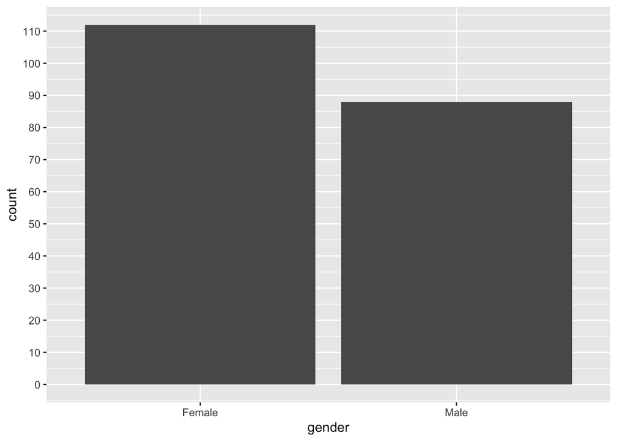

```r
ggplot(customers, (aes(gender))) +
  geom_bar() +
  scale_y_continuous(n.breaks = 11)
```

```r
customers %>%
  filter(gender == "Female") %>%
  count()
```

| n |
| --- |
| 112 |

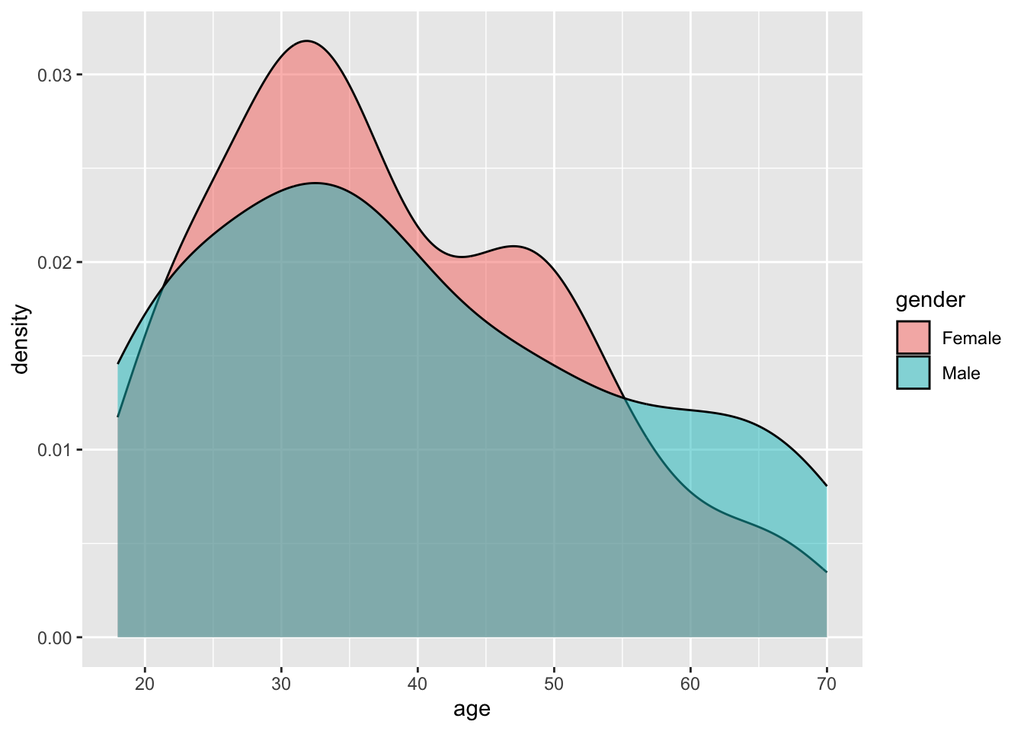

```r
ggplot(customers, aes(age, fill = gender)) +
  geom_density(alpha = 0.5)
```

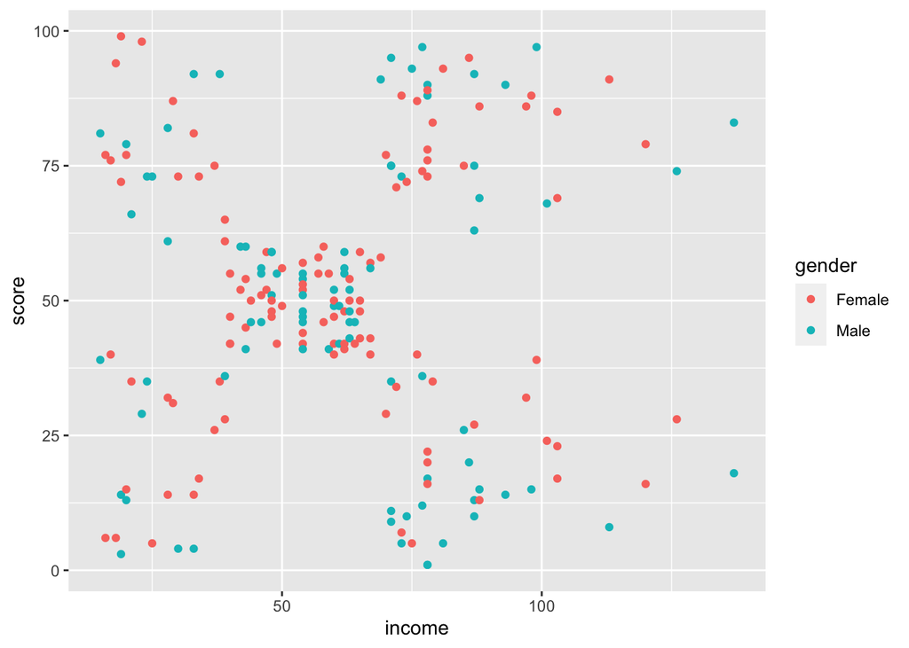

```r
ggplot(customers, aes(income, score, colour = gender)) +
  geom_point()
```

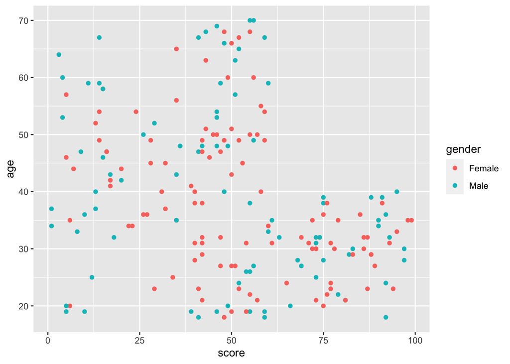

```r
ggplot(customers, aes(score, age, colour = gender)) +
  geom_point()
```

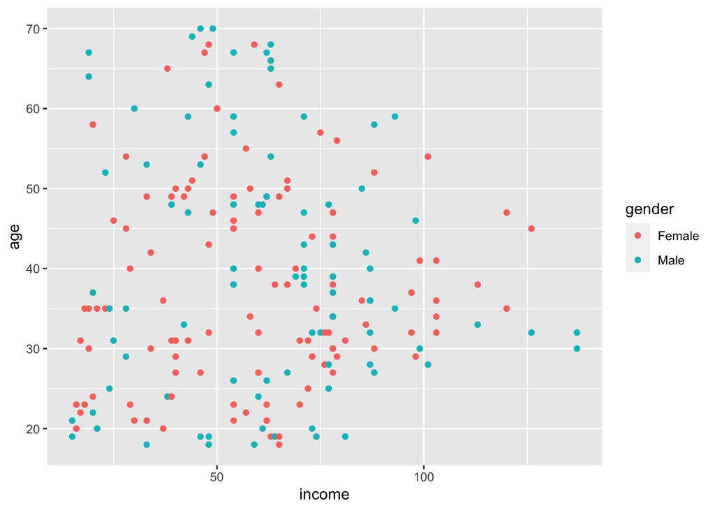

```r
ggplot(customers, aes(income, age, colour = gender)) +
  geom_point()
```

**Data Summary** - More females than males in the dataset (112 Female, 88 males) - The age spread is different for the genders. Larger number of females around 30 and late 40s early 50s years of age than males. More older males (> 55) than females. - The scatter plot shows a very interesting pattern - looks like some obvious clusters!

## 2. k-means clustering (meaningful clusters?)

Scale data The data is all on a similar scale so I’m not sure if needs scaled but maybe k-means is really sensitive. Lets try it both ways - on scaled and unscaled data.

Will need to change gender column to numeric if we want to use it.

```r
customers_clean <- customers %>%
  mutate(female = ifelse(gender == "Female", 1, 0)) %>%
  select(-gender)
```

```r
customers_scaled <- customers_clean %>%
  mutate(across(c(age, income, score), scale))
```

```r
diss_matrix <- customers_scaled %>%
  select(-customer_id) %>%
  dist(method = "euclidean")
```

Visualise distance matrix

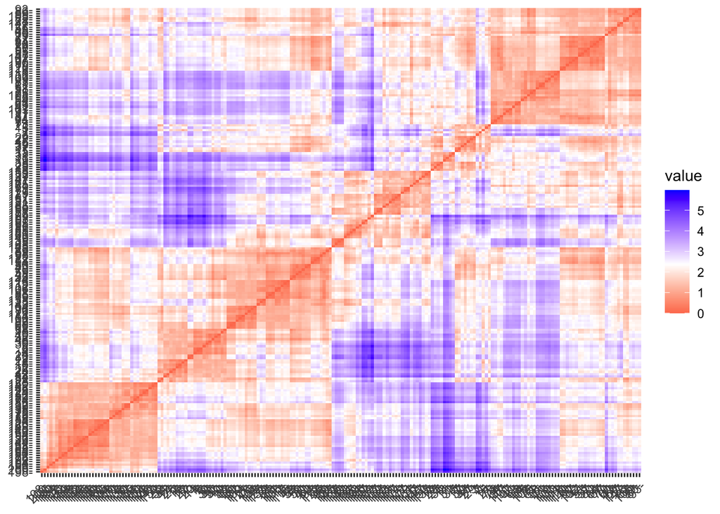

```r
diss_matrix %>%
  fviz_dist()
```

Looks like there are clusters of data points there.

## 3. k-means clustering and choose k value

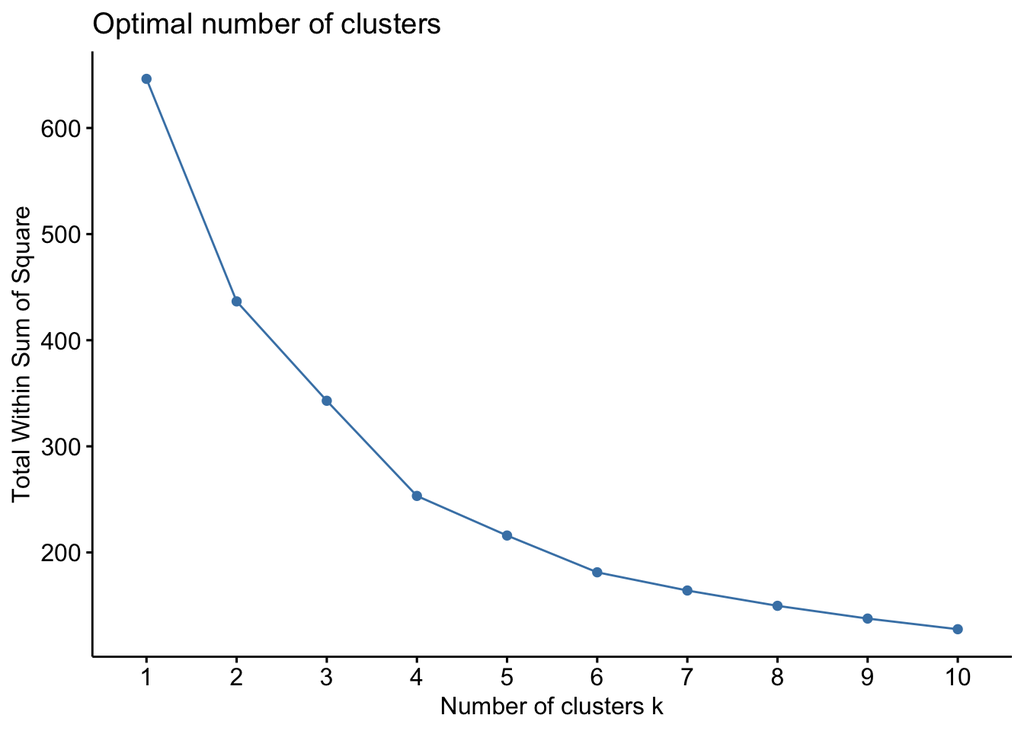

```r
fviz_nbclust(customers_scaled %>%  select(-customer_id),
             FUNcluster = kmeans,
             method = "wss",
             nstart = 20)
```

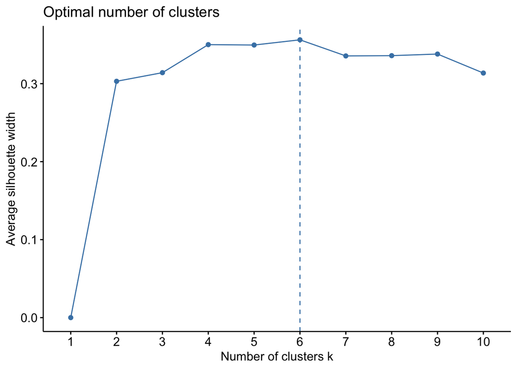

```r
fviz_nbclust(customers_scaled %>%  select(-customer_id),
             FUNcluster = kmeans,
             method = "silhouette",
             nstart = 20)
```

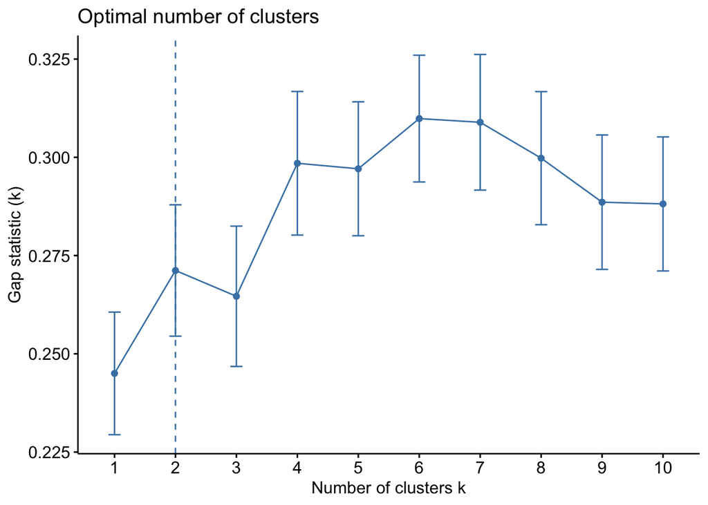

```r
fviz_nbclust(customers_scaled %>%  select(-customer_id),
             FUNcluster = kmeans,
             method = "gap_stat",
             nstart = 20)
```

elbow method = 4 silhouette = 6 gap = 2 (but it increases a lot after this and 6 is the highest before it decreases)

When we plotted income vs score there were 5 pretty distinct clusters so I would be inclined to go for at least 5 clusters. **Lets choose 6 clusters**

```r
kmeans6_cust_scaled <- kmeans(customers_scaled %>% select(-customer_id), centers = 6, nstart = 20)

kmeans6_cust_scaled
```

```
## K-means clustering with 6 clusters of sizes 45, 34, 39, 38, 23, 21
##
## Cluster means:
##          age     income       score    female
## 1  1.2515802 -0.2396117 -0.04388764 0.5777778
## 2  0.1728617  1.0637844 -1.29476121 0.4117647
## 3 -0.4408110  0.9891010  1.23640011 0.5384615
## 4 -0.8483065 -0.1485683 -0.04137395 0.6578947
## 5 -0.9914806 -1.3439751  1.06138489 0.5652174
## 6  0.4777583 -1.3049552 -1.19344867 0.6190476
##
## Clustering vector:
##   [1] 5 5 6 5 6 5 6 5 6 5 6 5 6 5 6 5 6 5 6 5 6 5 6 5 6 5 6 5 6 5 6 5 6 5 6 5 6
##  [38] 5 6 5 1 5 6 4 6 5 1 4 4 4 1 4 4 1 1 1 1 1 4 1 1 4 1 1 1 4 1 1 4 4 1 1 1 1
##  [75] 1 4 1 4 4 1 1 4 1 1 4 1 1 4 4 1 1 4 1 4 4 4 1 4 1 4 4 1 1 4 1 4 1 1 1 1 1
## [112] 4 4 4 4 4 1 1 1 1 4 4 4 3 4 3 2 3 2 3 2 3 4 3 2 3 2 3 2 3 2 3 4 3 2 3 2 3
## [149] 2 3 2 3 2 3 2 3 2 3 2 3 1 3 2 3 2 3 2 3 2 3 2 3 2 3 2 3 2 3 2 3 2 3 2 3 2
## [186] 3 2 3 2 3 2 3 2 3 2 3 2 3 2 3
##
## Within cluster sum of squares by cluster:
## [1] 34.84793 45.75370 32.05498 26.61632 16.53336 25.47570
##  (between_SS / total_SS =  71.9 %)
##
## Available components:
##
## [1] "cluster"      "centers"      "totss"        "withinss"     "tot.withinss"
## [6] "betweenss"    "size"         "iter"         "ifault"
```

Nice spread of data points in each cluster

## 4. visualise clusters

```r
kmeans6_tib <- kmeans6_cust_scaled$centers %>%
  as_tibble()
```

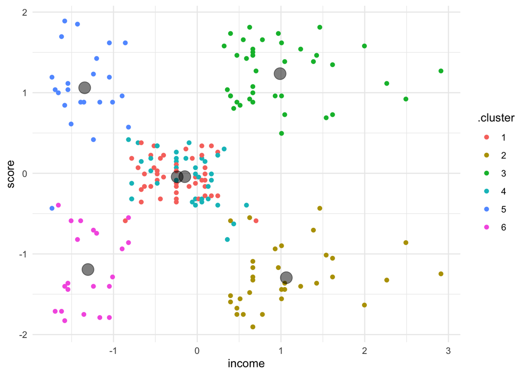

```r
  ggplot() +
  geom_point(data = augment(kmeans6_cust_scaled, customers_scaled),
             mapping = aes(income, score,
                           colour = .cluster)) +
  geom_point(data = kmeans6_tib,
             mapping = aes(income, score), size = 5, alpha = 0.5) +
  theme_minimal()
```

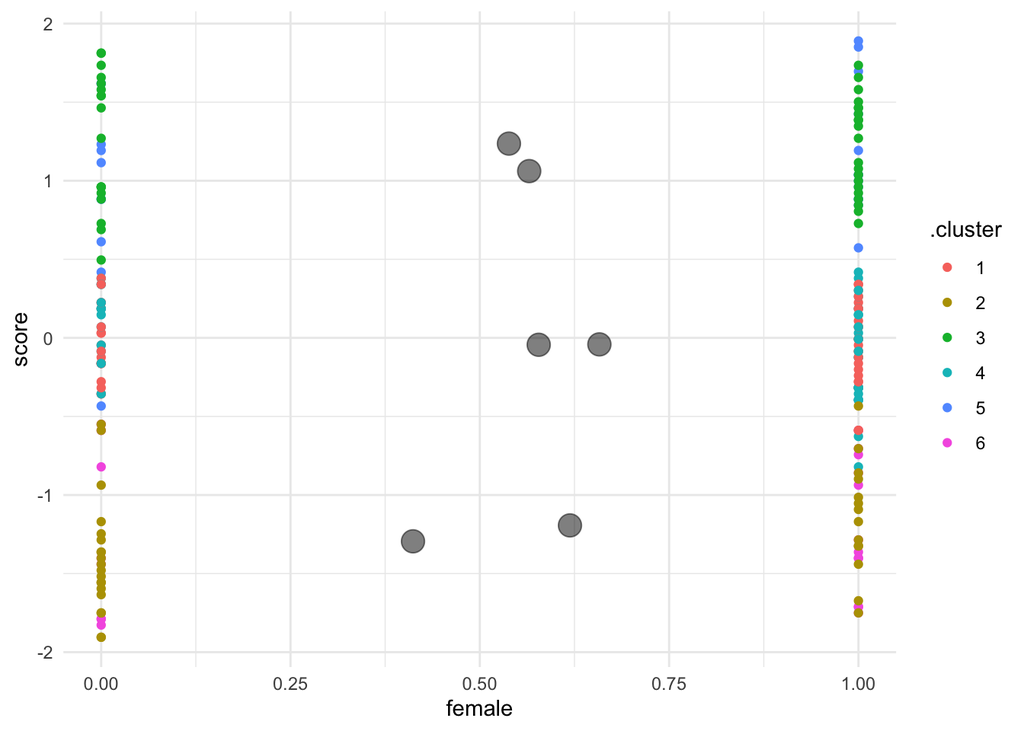

```r
  ggplot() +
  geom_point(data = augment(kmeans6_cust_scaled, customers_scaled),
             mapping = aes(female, score,
                           colour = .cluster)) +
  geom_point(data = kmeans6_tib,
             mapping = aes(female, score), size = 5, alpha = 0.5) +
  theme_minimal()
```

It doesn’t look as if gender has much influence on things as most of the clusters are sitting around 0.5. The two clusters in the middle must be separated by age - lets take a look.

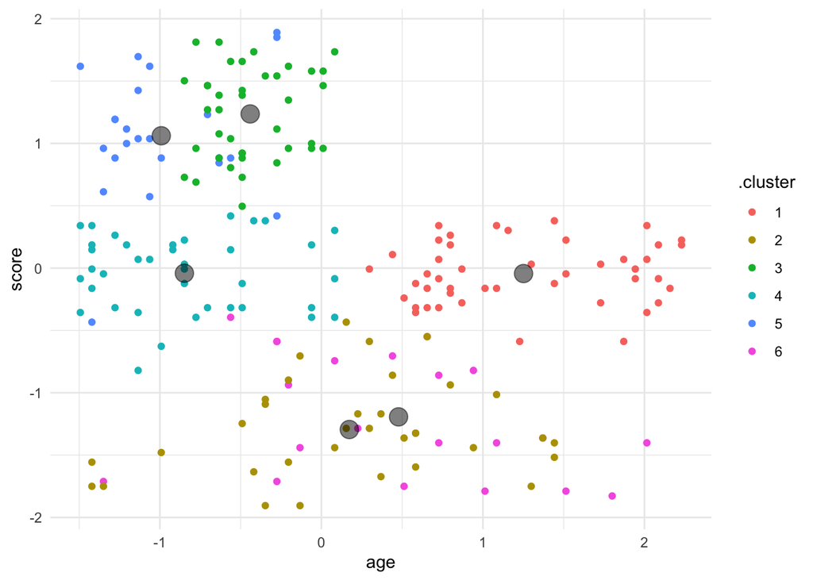

```r
  ggplot() +
  geom_point(data = augment(kmeans6_cust_scaled, customers_scaled),
             mapping = aes(age, score,
                           colour = .cluster)) +
  geom_point(data = kmeans6_tib,
             mapping = aes(age, score), size = 5, alpha = 0.5) +
  theme_minimal()
```

Can see thqt clusters 1 adn 4 are separated well by age.

## 6. Label clusters

Try clusters on unscaled data to see if it needs scaled.

```r
kmeans6_cust <- kmeans(customers_clean %>% select(-customer_id), centers = 6, nstart = 20)

kmeans6_cust
```

```
## K-means clustering with 6 clusters of sizes 39, 21, 35, 22, 45, 38
##
## Cluster means:
##        age   income    score    female
## 1 32.69231 86.53846 82.12821 0.5384615
## 2 44.14286 25.14286 19.52381 0.6190476
## 3 41.68571 88.22857 17.28571 0.4285714
## 4 25.27273 25.72727 79.36364 0.5909091
## 5 56.15556 53.37778 49.08889 0.5555556
## 6 27.00000 56.65789 49.13158 0.6578947
##
## Clustering vector:
##   [1] 2 4 2 4 2 4 2 4 2 4 2 4 2 4 2 4 2 4 2 4 2 4 2 4 2 4 2 4 2 4 2 4 2 4 2 4 2
##  [38] 4 2 4 5 4 5 6 2 4 5 6 6 6 5 6 6 5 5 5 5 5 6 5 5 6 5 5 5 6 5 5 6 6 5 5 5 5
##  [75] 5 6 5 6 6 5 5 6 5 5 6 5 5 6 6 5 5 6 5 6 6 6 5 6 5 6 6 5 5 6 5 6 5 5 5 5 5
## [112] 6 6 6 6 6 5 5 5 5 6 6 6 1 6 1 3 1 3 1 3 1 6 1 3 1 3 1 3 1 3 1 6 1 3 1 3 1
## [149] 3 1 3 1 3 1 3 1 3 1 3 1 3 1 3 1 3 1 3 1 3 1 3 1 3 1 3 1 3 1 3 1 3 1 3 1 3
## [186] 1 3 1 3 1 3 1 3 1 3 1 3 1 3 1
##
## Within cluster sum of squares by cluster:
## [1] 13982.051  7737.333 16699.429  4105.136  8073.244  7751.447
##  (between_SS / total_SS =  81.1 %)
##
## Available components:
##
## [1] "cluster"      "centers"      "totss"        "withinss"     "tot.withinss"
## [6] "betweenss"    "size"         "iter"         "ifault"
```

```r
kmeans6_tib_not_scaled <- kmeans6_cust$centers %>%
  as_tibble()
```

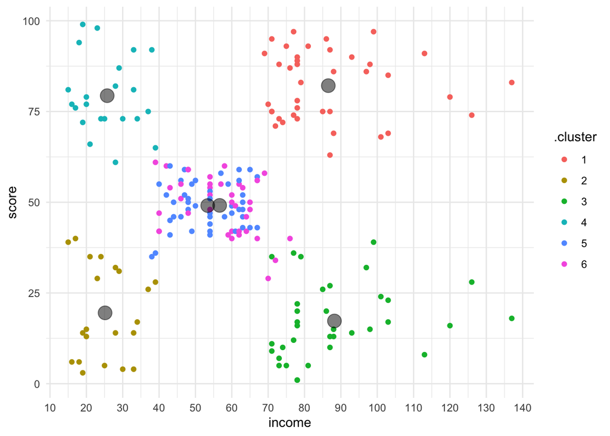

```r
  ggplot() +
  geom_point(data = augment(kmeans6_cust, customers_clean),
             mapping = aes(income, score,
                           colour = .cluster)) +
  geom_point(data = kmeans6_tib_not_scaled,
             mapping = aes(income, score), size = 5, alpha = 0.5) +
  theme_minimal() +
  scale_x_continuous(n.breaks = 12)
```

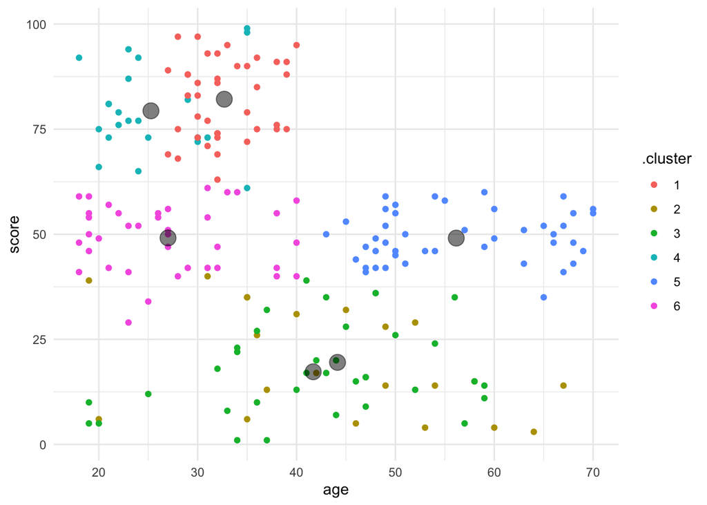

```r
  ggplot() +
  geom_point(data = augment(kmeans6_cust, customers_clean),
             mapping = aes(age, score,
                           colour = .cluster)) +
  geom_point(data = kmeans6_tib_not_scaled,
             mapping = aes(age, score), size = 5, alpha = 0.5) +
  theme_minimal()
```

So the data doesn’t need to be scaled. This will make interpretation easier.

[output not shown]

K-means clustering with 6 clusters of sizes 39, 21, 35, 22, 45, 38

medium spending score - >40 years old, mid earners (40-70k) medium spending score - <=40 years old, mid earners (40-70k)

low spening score - all ages, low earners (<40 k) low spending score - all ages, high earners (>70 k)